# Class 03: Assignment

William Mechler

## Get to know your break out room!

A few ice breakers to get the conversation started.

## Problem 1

An investigator is interested in the effects of sleep deprivation on memory function. He randomly assigns each of 60 participants to one of several study conditions. Fifteen subjects take a test of memory function after they have been awake for eight hours (No sleep deprivation). Fifteen subjects take the test after they have been awake for 18 hours (mild sleep deprivation). Fifteen subjects take the test after they have been awake four 24 hours (moderate sleep deprivation). Fifteen subjects take the test after they have been awake for 48 hours (severe sleep deprivation). Higher scores on the test of memory function indicate higher levels of performance.

Answer the following questions about the experimental design.

- What are the **Experimental Units** in this study?
  - **The 60 participants**
- What is the **response variable** in this study?
  - **Their scores on the test**
- What is the **factor** in this study?
  - **Hours awake**
- How many **factor levels** are there?
  - **4**
- What are the **treatments**?
  - **8 hours awake. 18 hours awake, 24 hours awake and 48 hours awake**
- Cite **two ways** that the researcher took to control for nuisance variables and unexplained variability.
  - **The researcher randomly assign each of the participants to each group.**
  - **The researcher used replication by assigning multiple experimental units per treatment.**

## Problem 2

For each of the scenarios described below, cite whether the problem is from an **observational study** or a **designed experiment**, and why.

- A group of scientists wanted to test a new drug that’s made to help people suppress their alcohol addiction. The scientists gathers a random sample of 200 alcoholics and then divides them into two groups; one receiving the drug and the other a placebo. They then will collect data on if the drug is effective or not.

**The above scenario is an designed experiment as the scientists designed how they would test the new drug. By gather a random sample of people and putting them into groups to collect data.**

- A group of students wanted to know if there is a relationship between attending after school activities and GPA. They then use a survey to gather their data from students who do attend after school activities and who doesn’t attend and ask for their current GPA.

**The above scenario is an observational study as the students running the experiment didn’t plan or design a test for their experiment. Instead they simply asked and observed the result of their survey.**

## Problem 3

A small experiment was conducted to test the impact lathe speed has on the *surface Finish* (a measure of the overall texture of a surface characterized by the lay, roughness and waviness of the surface). Nine pieces of metal were run through a lathe at three speeds (500, 700 and 900 rpm) sequentially (three at the 500 rpm speed, then three at 700 rpm and lastly three at 900 rpm) and the surface finish (roughness measured in micrometers) of each was measured; the same lathe was used for all nine pieces using the same lathe operator. The data is input into R in the code chunk below.

```r
lathe_data <- data.frame(Speed = factor(c(500,500,500, 700,700,700, 900,900,900)),
                         Finish = c(8,13,12, 10,16,14, 18,22,18) )

lathe_data %>%
        kable()
```

| Speed | Finish |
| --- | --- |
| 500 | 8 |
| 500 | 13 |
| 500 | 12 |
| 700 | 10 |
| 700 | 16 |
| 700 | 14 |
| 900 | 18 |
| 900 | 22 |
| 900 | 18 |

Source: Experimental Design & Analysis Reference by ReliaSoft Corporation.

The **experimental units** in this experiment are the nine pieces of metal since they are what is being measured. The **response variable** is the surface finish (roughness), with a single **factor** in the experiment, lathe speed, with three **factor levels** or **treatments**, 500 rpm, 700 rpm and 900 rpm.

1. Discuss the limitations of this experiments. In particular, discuss how the principle of **randomization** is being violated and could be improved upon. How improvement in this area might dissipate any issues in the current experiment.

**There were not enough experimental units per treatment and also the lathe were used multiple times for each factor level. You could improve this by increasing the about the amount of experimental units and using different lathes per run.**

2. Ignoring the issues with randomization you discussed above. Build an effective descriptive statistics table or graph to summarize the surface finish as a function of lathe speed. Does it appear lathe speed may influence surface finish?

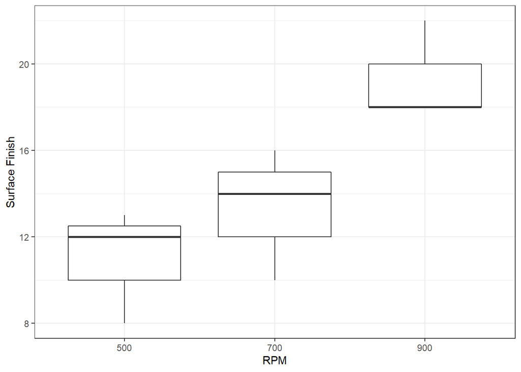

```r
ggplot(lathe_data, aes(x=Speed, y=Finish)) +
  geom_boxplot() +
  labs(x="RPM", y="Surface Finish") +
  theme_bw()
```

```r
lathe_data %>%
  group_by(Speed) %>%
  summarize(Mean=mean(Finish),
            SD=sd(Finish),
            Min=min(Finish),
            Q1 = quantile(Finish, prob=0.25),
            Median=median(Finish),
            Q3 = quantile(Finish, prob=0.75),
            Max=max(Finish)) %>%
  kable()
```

| Speed | Mean | SD | Min | Q1 | Median | Q3 | Max |
| --- | --- | --- | --- | --- | --- | --- | --- |
| 500 | 11.00000 | 2.645751 | 8 | 10 | 12 | 12.5 | 13 |
| 700 | 13.33333 | 3.055051 | 10 | 12 | 14 | 15.0 | 16 |
| 900 | 19.33333 | 2.309401 | 18 | 18 | 18 | 20.0 | 22 |

**From the above graph it appears that the speed does influence the finish. As is seems that the higher the RPM the higher the surface finish score.**

3. Ignoring the issues with randomization, perform the appropriate ANOVA $F$-test at $\alpha=1\%$ to statistically determine if there is a difference in mean surface finish for the three lathe speeds.

```r
lathe_data.anove <- aov(Finish ~ Speed, data=lathe_data)
```

```r
summary(lathe_data.anove)
```

```
##             Df Sum Sq Mean Sq F value Pr(>F)
## Speed        2 110.89   55.44   7.677 0.0222 *
## Residuals    6  43.33    7.22
## ---
## Signif. codes:  0 '***' 0.001 '**' 0.01 '*' 0.05 '.' 0.1 ' ' 1
```

**Because our p-value is greater than the alpha of 1% we don’t have enough evidence to statistically determine if there is a difference in the mean of surface finish based on their speed.**

4. In addition to the issues in this experiment regarding randomization, you may note a general lack of replication (only three runs per treatment). Comment on the limitations of this experiment due to the lack of replication and relate those comments to the findings in parts b. and c. of this problem.

**Do to our limited data set we may not be able to trust our results. We could fix this by adding more experiment units per treatment can help us in this. While in part b the graphs looked clear, having more data points to graph can help us cement the trends in our data.**